# Proyecto Individual: Redes Neuronales

*Curso Propedéutico: Álgebra Líneal y Optimización*

*Vesna Camile Pivac Alcaraz*

## 1. Definición y ejemplos de redes neuronales

### 1.1 Definición

Las redes neuronales son sistemas computacionales y matemáticos que se inspiran en la estructura y el funcionamiento del cerebro humano. Estos modelos se desarrollan con el propósito de procesar información y tienen la capacidad de aprender y reconocer patrones complejos a través de la adaptación de sus conexiones internas. Estas conexiones se organizan en capas y permiten que la red neuronal lleve a cabo tareas de clasificación, reconocimiento de patrones, predicción y toma de decisiones. Mediante el procesamiento de datos de entrada, las redes neuronales realizan operaciones matemáticas y ajustan los pesos de las conexiones internas para obtener resultados precisos y sofisticados. Esta capacidad de aprendizaje y adaptación de las redes neuronales las convierte en una herramienta poderosa en campos como la inteligencia artificial, el reconocimiento de voz, la visión por computadora y muchas otras aplicaciones en las que se requiere el procesamiento y análisis de grandes cantidades de información de manera eficiente y precisa.

Las neuronas artificiales son componentes esenciales de las redes neuronales, también conocidas como redes de neuronas artificiales. Estas unidades se denominan "artificiales" debido a su inspiración en las neuronas biológicas del cerebro humano.

[figure not shown]

Cada neurona artificial en una red neuronal recibe un conjunto de valores de entrada. Estos valores de entrada pueden representar características o variables relevantes del problema que la red está tratando de resolver. Cada valor de entrada se multiplica por un peso sináptico, que determina la importancia o contribución relativa de ese valor en la salida de la neurona. Estos pesos sinápticos se ajustan durante el proceso de entrenamiento de la red neuronal para optimizar el rendimiento de la red.

Después de ponderar los valores de entrada, se realiza una suma ponderada de estos valores. Esta suma puede considerarse como una combinación lineal de las entradas ponderadas. Posteriormente, la suma ponderada se pasa a través de una función no lineal llamada función de activación. La función de activación introduce la capacidad de no linealidad en la neurona artificial y es esencial para que la red pueda aprender y representar relaciones complejas entre los datos de entrada y la salida esperada.

[figure not shown]

La función de activación puede ser de varios tipos, como la función sigmoide, la función ReLU, la función tangente hiperbólica, entre otras. Estas funciones no lineales introducen la capacidad de modelar relaciones no lineales entre los datos, lo que permite a la red neuronal capturar patrones y características más complejas en los datos de entrada.

[figure not shown]

Finalmente, la salida de la neurona artificial, que es el resultado de la función de activación, se pasa a otras neuronas en la siguiente capa de la red neuronal. De esta manera, la información fluye a través de la red neuronal, pasando por múltiples capas de neuronas, y cada neurona realiza su cálculo y contribución específica para el procesamiento de la información y la generación de la salida final de la red.

### 1.2 Modelo de una red neuronal simple

Un modelo de una red neuronal simple consiste en la interconexión de neuronas artificiales en tres capas distintas: la capa de entrada, la capa oculta y la capa de salida.

- **Capa de entrada**: Es la primera capa de la red neuronal y se encarga de recibir los datos de entrada que serán procesados. Cada nodo de esta capa representa una característica o variable de entrada. Los nodos de la capa de entrada analizan o clasifican estos datos y los transmiten a la siguiente capa, que es la capa oculta.
- **Capa oculta**: Es una capa intermedia entre la capa de entrada y la capa de salida. Los nodos de la capa oculta reciben los datos procesados provenientes de la capa de entrada o de otra capa oculta y realizan un procesamiento adicional. Esta capa puede contener uno o varios nodos, y cada nodo tiene conexiones con todos los nodos de la capa anterior y de la capa siguiente. La cantidad de capas ocultas y el número de nodos en cada capa oculta pueden variar según la complejidad del problema que se esté abordando.
- **Capa de salida**: Es la última capa de la red neuronal y proporciona el resultado final. Los nodos de esta capa representan las salidas deseadas o las clases a las que se quiere asignar los datos de entrada. La cantidad de nodos en la capa de salida dependerá del tipo de resultado que se busca obtener. Por ejemplo, si se trata de un problema de clasificación con varias clases, habrá un nodo en la capa de salida para cada clase posible.

[figure not shown]

```
I = Datos de entrada
O = Datos de salida
```

### 1.3 Arquitecturas de redes neuronales

Existen diversas arquitecturas de redes neuronales, la siguiente imagen muestra las capas y tipos de neuronas dentro de cada tipo de red neuronal.

[figure not shown]

A continuación se explican las principales redes neuronales:

- **Perceptrón**: El perceptrón es una de las arquitecturas más básicas de una red neuronal, introducida por Frank Rosenblatt en 1957. Consiste en una única capa de neuronas, también conocida como capa de salida. Este algoritmo se utiliza principalmente para el aprendizaje supervisado de clasificadores binarios, es decir, para resolver problemas en los que se debe asignar una entrada a una de dos categorías posibles.

  Los componentes básicos de un perceptrón son los siguientes:
  - Capa de entrada (Inputs): La capa de entrada recibe las entradas que serán procesadas por la red neuronal. Cada entrada está asociada a una neurona de la capa de entrada.
  - Pesos (Weights): Cada neurona de la capa de entrada tiene asociado un peso, que representa la fuerza de la conexión entre la neurona de entrada y la neurona de salida. Los pesos determinan la importancia relativa de cada entrada en la salida del perceptrón.
  - Bias: Se añade un término de bias a la capa de entrada del perceptrón. El bias es una constante que se suma a la combinación lineal de las entradas ponderadas por los pesos. Este término de bias proporciona al perceptrón una flexibilidad adicional para modelar patrones complejos en los datos de entrada.
  - Función de activación (Activation function): La función de activación determina la salida del perceptrón basándose en la suma ponderada de las entradas, el término de bias y, en algunos casos, la aplicación de un umbral. La función de activación introduce la capacidad de no linealidad en el perceptrón y define cómo se mapean las entradas a la salida del perceptrón.
  - Salida (Output): El resultado de salida de un perceptrón es un valor binario, generalmente 0 o 1, que representa la clasificación o la decisión tomada por el perceptrón.

[figure not shown]

- **Feedforward (FNN)**: Las redes neuronales de alimentación directa, también conocidas como feedforward, son un tipo de arquitectura de redes neuronales en las que la información fluye en una dirección específica, desde la capa de entrada hasta la capa de salida, sin formar bucles o retroalimentación. Son uno de los tipos más comunes y ampliamente utilizados de redes neuronales.

  Cada capa de la red está formada por un conjunto de neuronas artificiales (nodos) que realizan operaciones matemáticas en los datos de entrada. Cada neurona en una capa está conectada a todas las neuronas de la capa anterior y a todas las neuronas de la capa siguiente. Estas conexiones se representan mediante pesos sinápticos, que determinan la fuerza y la influencia de la conexión entre las neuronas.
- **Recurrentes (RNN)**: Las redes neuronales recurrentes (RNN) son un tipo de arquitectura de redes neuronales que utilizan conexiones recurrentes, lo que les permite tener memoria interna y capturar información contextual. A diferencia de las redes neuronales feedforward, las RNN tienen la capacidad de procesar secuencias de datos, como texto, audio o series de tiempo, al tener en cuenta la información anterior en el flujo de datos.

  La característica distintiva de las RNN es que comparten los mismos pesos a lo largo de la secuencia de datos. Esto significa que cada neurona en la red realiza la misma operación en cada paso de tiempo, utilizando tanto la entrada actual como la información que ha sido procesada anteriormente. Esta propiedad de compartir pesos a lo largo del tiempo les permite capturar y modelar patrones a lo largo de la secuencia y aprender dependencias a largo plazo en los datos secuenciales.

[figure not shown]

- **Convolucionales (CNN)**: Las redes neuronales convolucionales (CNN) son un tipo de arquitectura de redes neuronales especialmente diseñadas para procesar datos con estructura de cuadrícula, como imágenes. Estas redes han demostrado ser altamente efectivas en aplicaciones de visión por computadora, como reconocimiento de objetos, segmentación de imágenes y detección de características visuales.

  La arquitectura de una CNN típica consta de varias capas principales:
  - Capa de entrada: Recibe la imagen de entrada y la pasa a través de la red. Cada imagen se representa como una matriz bidimensional de píxeles, donde cada píxel contiene información de color.
  - Capas convolucionales: Estas capas son responsables de extraer características relevantes de la entrada. Cada capa convolucional aplica múltiples filtros convolucionales a la imagen de entrada. Cada filtro es una matriz de pesos que se desliza sobre la imagen para realizar operaciones de convolución. Estos filtros detectan patrones visuales específicos, como bordes, texturas o formas, y generan mapas de características que resaltan la presencia de estas características en la imagen.
  - Capas de activación: Después de cada capa convolucional, se aplica una función de activación no lineal para introducir no linealidades en la red y permitir la representación de características más complejas. Una función de activación comúnmente utilizada en las CNN es la función ReLU (Rectified Linear Unit), que mapea los valores negativos a cero y mantiene los valores positivos sin cambios.
  - Capas de pooling: Estas capas reducen la dimensionalidad espacial de los mapas de características mediante el muestreo o submuestreo de las activaciones más relevantes. El objetivo es disminuir la cantidad de parámetros y la complejidad computacional de la red, al tiempo que se preservan las características más importantes. Las operaciones de pooling más comunes son el max pooling, que selecciona el valor máximo de una región, y el average pooling, que calcula el promedio de los valores de una región.
  - Capas completamente conectadas: Al final de la red, se utilizan capas totalmente conectadas para realizar la clasificación final o hacer predicciones basadas en las características extraídas. Estas capas están organizadas como en una red neuronal feedforward tradicional, donde cada neurona está conectada a todas las neuronas de la capa anterior. Las capas totalmente conectadas pueden incluir funciones de activación adicionales y se utilizan para capturar relaciones más complejas entre las características extraídas.

[figure not shown]

## 2. Esquema matemático de las redes neuronales

### 2.1 Desarrollo matemático de una regresion lineal

Las señales de entrada, la información que recibe nuestra neuronal artificial, son variables independientes. Los n-valores de entrada son multiplicados por sus respectivos pesos, es decir en la sinopsis el vector entrada es multiplicado por el vector peso, dando como resultado una combinación lineal de las entradas y los pesos, algo que denominamos función de ponderación.

La capa de entrada, también conocida como la capa cero, de la red sirve para redistribuir los valores de entrada y no realiza ningún procesamiento. Las salidas de esta capa se describen matemáticamente por $o_{i}=x_{i}$ donde $i=1,...,N$ , xi representa el vector de entrada y N representa el número de neuronas en la capa de entrada.

La entrada para cada neurona en la primera capa oculta de la red es la suma ponderada de todas las conexiones entre la capa de entrada y la neurona en la capa oculta. Podemos escribir la entrada de red de una neurona de la primera capa como el producto entre el vector de entrada, xi , y el peso, wi , además del bias, θ. $$ Suma Ponderada = \sum_{i=1}^{N} w_{i}x_{i} + \theta $$ La función de activación transforma la suma ponderada para producir un nuevo valor de salida de la neurona. Con backpropagation esta función casi siempre es una sigmoide o una función lineal. La salida esta dada por la siguiente ecuación: $$ Salida = f(Suma Ponderada) = f(\sum_{i=1}^{N} w_{i}x_{i} + \theta) $$

Las redes neuronales surgen como una rama de la IA con una fuerte inspiración neurobiológica y su desarrollo ha sido debido a la contribución de investigadores procedentes de una gran variedad de disciplinas. A continuación, se presenta una tabla en la que se pone de manifiesto que las RNA y la estadística utilizan términos diferentes para nombrar el mismo objeto.

[figure not shown]

De forma análoga, se puede establecer una similitud entre modelos estadísticos y modelos de redes neuronales:

[figure not shown]

Estas son las representaciones matemáticas de los principales modelos de perceptrón utilizando distintas funciones de activación:

- **Perceptrón simple con función de activación lineal** en la neurona de salida y utilizando la suma del error cuadrático equivale a un modelo de regresión lineal:

[figure not shown]

```
      La representación matemática viene dada:
```

[figure not shown]

- **Perceptrón simple con función de activación logistica** en la neurona de salida es similar a un modelo de regresión logística:

[figure not shown]

```
    La representación matemática viene dada:
```

[figure not shown]

- **Perceptrón simple con función de activación umbral** en la neurona de salida es similar a la Función Discriminante Lineal de Fisher:

[figure not shown]

```
    La representación matemática viene dada:
```

[figure not shown]

## 3. Problema de interes: "MaskDetectNet: Identificacion precisa del uso de cubrebocas en personas con una Red Neuronal Convolucional basada en VGG16 "

Este proyecto se centra en el desarrollo de un clasificador de imágenes que pueda distinguir entre personas que usan o no mascarillas. El objetivo principal es utilizar una Red Neuronal Convolucional (CNN), una arquitectura de aprendizaje profundo especialmente diseñada para el procesamiento de imágenes, para lograr esta tarea.

En el contexto actual, donde el uso de mascarillas se ha vuelto crucial para la prevención de enfermedades y la seguridad pública, contar con un sistema automatizado capaz de detectar si una persona está usando una mascarilla puede ser de gran utilidad. Esto podría aplicarse en entornos como hospitales, aeropuertos, estaciones de transporte público, lugares de trabajo, entre otros, donde es importante garantizar el cumplimiento de las medidas de protección.

El desarrollo de este clasificador de imágenes implica varios desafíos. En primer lugar, se requiere un conjunto de datos etiquetados que contenga imágenes de personas con y sin mascarillas para entrenar la red neuronal. Estas imágenes deben ser representativas de las posibles variaciones en el uso de mascarillas, como diferentes tipos de mascarillas, colores, posiciones en la cara, fondos, etc.

Una vez que se tiene un conjunto de datos adecuado, se procede a diseñar y entrenar la CNN. Esto implica definir la arquitectura de la red, que incluye la cantidad y configuración de las capas convolucionales, las funciones de activación, las capas de pooling y las capas completamente conectadas. Además, se deben establecer los hiperparámetros de la red, como el tamaño de los filtros convolucionales, las tasas de aprendizaje y los tamaños de las capas ocultas.

El siguiente paso es entrenar la CNN utilizando el conjunto de datos etiquetados. Durante el entrenamiento, la red aprenderá a reconocer patrones y características relevantes que distingan entre personas con y sin mascarillas. Esto se logra mediante la optimización de los pesos de la red utilizando técnicas de aprendizaje supervisado y algoritmos de retropropagación del error.

### Dataset

Se utilizara un dataset de Kaggle: [FaceMask Dataset](https://www.kaggle.com/datasets/bitmasksabuj/facemask-dataset)

En el dataset se encuentran dos carpetas:

- **mask**: 1281 imagenes con mascarilla
- **no_mask**: 1486 imagenes de personas sin mascarilla

El dataset se dividira de la siguiente manera:

- Train: 70%
- Test: 20%
- Validation: 10%

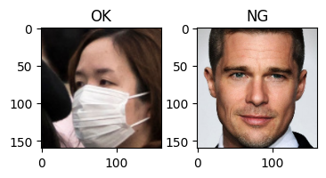

```python
import matplotlib.pyplot as plt
import matplotlib.image as mpimg

# Leer las imágenes
imagen1 = mpimg.imread('./dataset-mask/mask/31.png')
imagen2 = mpimg.imread('./dataset-mask/no_mask/20.png')

# Crear una figura y los subplots
fig, ax = plt.subplots(1, 2, figsize=(4, 2))  # 1 fila, 2 columnas

# Mostrar las imágenes en los subplots
ax[0].imshow(imagen1)
ax[0].set_title('OK')
ax[1].imshow(imagen2)
ax[1].set_title('NG')

# Ajustar el espacio entre los subplots
plt.subplots_adjust(wspace=0.3)

plt.show()  # Mostrar la figura en una ventana emergente
```

### Arquitectura de VGG16

En este proyecto, se ha tomado la decisión de utilizar la arquitectura de red neuronal convolucional VGG16 para clasificar imágenes de personas con y sin cubrebocas. La elección de VGG16 se basa en varias consideraciones.

En primer lugar, VGG16 es una red neuronal convolucional muy conocida y ampliamente utilizada en tareas de clasificación de imágenes. Fue desarrollada por el Grupo de Visión por Computadora y Aprendizaje Automático de la Universidad de Oxford y ha demostrado un buen rendimiento en una variedad de conjuntos de datos.

Además, VGG16 es una red preentrenada, lo que significa que ha sido entrenada previamente en un conjunto de datos masivo, en este caso, la base de datos ImageNet, que contiene millones de imágenes de diferentes categorías. Esto implica que VGG16 ya ha aprendido características visuales generales y puede ser utilizado como una excelente base para transferir ese conocimiento a nuestro problema específico de clasificación de personas con y sin cubrebocas.

Una de las ventajas de utilizar una red preentrenada como VGG16 es que nos permite aprovechar el conocimiento previo adquirido por la red en tareas de clasificación de imágenes generales. Esto puede ayudar a acelerar el proceso de entrenamiento y mejorar el rendimiento del clasificador, especialmente si nuestro conjunto de datos de personas con y sin cubrebocas es relativamente pequeño.

Es importante destacar que VGG16 está diseñada para trabajar con imágenes de tamaño fijo. En este caso, las imágenes se redimensionarán a un tamaño de 224x224 píxeles antes de ser procesadas por la red. Este tamaño es compatible con la arquitectura de VGG16 y garantiza un procesamiento uniforme de todas las imágenes de entrada.

La red neuronal convolucional preentrenada VGG16 esta compuesta por las siguientes capas:

[figure not shown]

- **Capa de entrada**: Esta capa representa la entrada de la imagen al modelo y tiene dimensiones fijas que corresponden al tamaño de la imagen de entrada la cual tiene un tamaño de 224x224.
- **Capas convolucionales**: La red tiene 13 capas convolucionales en distintas etapas de la arquitectura, dentro de estas se encuentran filtros de convolución (Kernel) para extraer características de la imagen. El tamaño de estos filtros son de 3x3 con un paso de 1 y se aplican convoluciones de relleno (padding) para mantener el tamaño de la imagen.

[figure not shown]

- **Capas de agrupación (pooling)**: Se utilizan despues de varias capas de convolucion para reducir la dimensionalidad y tamaño espacial de las características extraídas. En esta red se utilizan de tipo Max Pooling la cual calcula el valor máximo de las sub-areas de un mapa de características y lo utiliza para generar otro mapa de características pero reducido.

[figure not shown]

- **Capa Flatten**: Antes de conectar las capas convolucionales y de agrupación a las capas completamente conectadas, se utiliza una capa Flatten. Esta capa convierte la entrada multidimensional en una única dimensión, lo que permite que las capas densas posteriores puedan procesarla adecuadamente.

[figure not shown]

- **Capas completamente conectadas**: Después de pasar por las capas convolucionales y de agrupación, la información se encuentra reducida a características más abstractas y de alto nivel. Las capas completamente conectadas toman estas características y alimentan cada una de las neuronas de su capa. Estas capas densas pueden considerar toda la información y aprender relaciones complejas entre ellas. En estas capas, se utiliza la función de activación ReLU para introducir no linealidad en el modelo y permitir la representación de relaciones más complejas.

[figure not shown]

- **Capa de salida**: La capa de salida tiene el mismo número de neuronas que el número de clases a predecir. Cada neurona representa una clase distinta y produce un valor de salida asociado a la probabilidad de que la imagen pertenezca a esa clase. La clase con la probabilidad más alta se considera la predicción final del modelo.

### Desarrollo Matemátematico

#### Entrada

En el caso de la capa de entrada de una red neuronal convolucional, se utiliza una imagen RGB que se representa como un tensor tridimensional con dimensiones (ancho, alto, canales). Supongamos que la entrada tiene una anchura de W, una altura de H y tres canales (rojo, verde y azul).

[figure not shown]

Para la explicación nos enfocaremos en la primera dimensión del tensor, la cual podemos representar como una matriz con n renglones y m columnas, donde cada elemento de la matriz corresponde a un píxel de la imagen y contiene los valores de intensidad de un solo canal.

Denotemos esta matriz como $\mathcal{M}_{n\times m}(\mathbb{R})$, donde $n$ representa la altura (H) de la imagen y $m$ representa la anchura (W) de la imagen. La matriz $\mathcal{M}$ pertenece al conjunto de matrices de tamaño $n\times m$ con elementos en el conjunto de los números reales ($\mathbb{R}$).

Cada elemento de la matriz $\mathcal{M}$ se puede representar como $x_{ij}$, donde $i$ indica el índice del renglón y $j$ indica el índice de la columna. El valor de $x_{ij}$ corresponde a la intensidad de uno de los canales RGB en el píxel de la imagen en la posición $(i, j)$.

#### Capa Convolucional

En una capa convolucional, se realizan operaciones de convolución entre una matriz de entrada y un kernel (un conjunto de kernels es un filtro). El kernel es una matriz de pesos que se aplica a la matriz de entrada para realizar la operación de convolución.

Supongamos que tenemos un kernel de 3x3 en esta capa de convolución que multiplica a la matriz M, podemos representarlo de la siguiente manera: $$ \begin{equation} \begin{pmatrix} a_{1,1} & a_{1,2} & a_{1,3}\\ a_{2,1} & a_{2,2} & a_{2,3}\\ a_{3,1} & a_{3,2} & a_{3,3}\\ \end{pmatrix} \end{equation} $$

que al aplicar la convolución a nuestra matriz obtendriamos que cada elemento resultante tendria la forma de:

$$ e_{i,j}= e_{i-1,j-1}a_{1,1} + e_{i,j-1}a_{1,2} + e_{i+1,j-1}a_{1,3} + e_{i-1,j}a_{2,1} + e_{i,j}a_{2,2} + e_{i+1,j}a_{2,3} + e_{i-1,j+1}a_{3,1} + e_{i,j+1}a_{3,2} + e_{i+1,j+1}a_{3,3}\\\ $$

[figure not shown]

La aplicación de un kernel a una matriz se puede visualizar como efectos para la imagen de manera que algunos puedan sacar distintos tipos de caracteristicas, por ejemplo los que muestra la siguiente imagen:

[figure not shown]

Al terminar de realizar esta operación se le aplica la función de activación ReLu que te devuelve puros positivo de tal manera que la matriz resultante sera una con puros valores positivos y ceros si es que existen negativos. $$ ReLu(x) = Max(0,x) $$

[figure not shown]

#### Capa de Agrupamiento (Pooling)

La capa de agrupación (pooling) tiene como objetivo reducir la dimensionalidad espacial de las características extraídas por las capas convolucionales. En particular, el tipo de operación de agrupación más comúnmente utilizado es el Max Pooling.

En el Max Pooling, se divide la matriz de entrada en regiones no superpuestas, generalmente de tamaño 2x2, y se selecciona el valor máximo de cada región. Esto implica que la capa de agrupación selecciona las características más prominentes o relevantes de cada región y las mantiene en el mapa de características resultante. De esta manera, el tamaño de la matriz se reduce en un factor de 2.

El uso del Max Pooling en la VGG16 permite reducir la dimensionalidad y el tamaño espacial de las características extraídas, al mismo tiempo que preserva las características más importantes. Esto es beneficioso porque reduce la cantidad de parámetros y la complejidad computacional de la red, al tiempo que mantiene la información esencial para el proceso de clasificación.

[figure not shown]

Durante el backpropagation en la capa de Max Pooling, no se realizan cálculos específicos en esta capa, ya que no hay parámetros entrenables en ella. En cambio, los gradientes se propagan desde las capas posteriores a través de las capas convolucionales anteriores, utilizando la regla de la cadena, para ajustar los pesos y los sesgos de esas capas.

[figure not shown]

#### Capa Flatten

Esta es la representación grafica de; resultado de la capa flatten al aplicarla a una matriz:

[figure not shown]

#### Capa Completamente Conectada

Una capa completamente conectada toma como entrada un vector de características unidimensional y aplica una transformación lineal seguida de una función de activación no lineal. La transformación lineal se realiza mediante una matriz de pesos (W) y un vector de sesgos (b).

#### Capa de Salida

La capa de salida es la capa final de la red neuronal que produce resultados. En el caso que la red neuronal sea una de clasificación binaria tendra una sola neurona con una función de activación sigmoide. Si fuera una de clasificación multiclase por lo general la capa de salida tiene el mismo número de neuronas que de clases.

#### Forward Propagation y Backpropagation

Todo el proceso anteriormente mencionado se le llama forward propagation ya que va de la entrada a la salida sin regresarse en ninguna de las capas. En las redes convolucionales se aplica el backpropagation para poder ajustar los pesos de la red neuronal que en este caso seria los kernels o los filtros, esto para poder aproximar mejor nuestra clasificación o para obtener una mejor presición para tener una predicción correcta.

[figure not shown]

### Solución del problema

Una vez que aplicamos el algoritmo a nuestro conjunto de datos para clasificar imágenes de personas con y sin cubrebocas, las imágenes son procesadas por las capas de convolución y agrupamiento (pooling) en la red neuronal convolucional. Estas capas se encargan de extraer las características únicas de cada imagen mediante la convolución de filtros y la reducción de dimensionalidad.

La capa de convolución aplica filtros a las imágenes para detectar características locales, como bordes, texturas o patrones específicos. Cada filtro se desliza por la imagen, realizando multiplicaciones entre sus valores y los píxeles correspondientes en la región de la imagen cubierta por el filtro. Luego, se suman los resultados y se obtiene un valor que representa la presencia o ausencia de la característica detectada.

A continuación, la capa de agrupamiento (pooling) reduce la dimensionalidad de las características extraídas. En particular, la operación de agrupamiento MaxPooling selecciona el valor máximo en una región definida, generalmente de tamaño 2x2, y lo utiliza como representación de esa región. Esto reduce el tamaño espacial de las características y ayuda a conservar las características más relevantes.

Después de pasar por las capas de convolución y agrupamiento, la información se encuentra en forma de mapas de características multidimensionales. La capa Flatten se utiliza para convertir estos mapas en un vector unidimensional. Esta capa simplemente reorganiza los valores de los mapas de características en un único vector, manteniendo el orden de los elementos.

El vector resultante se alimenta a las capas completamente conectadas, que son capas densas donde cada neurona se conecta con todas las neuronas de la capa anterior. Estas capas utilizan funciones de activación para detectar patrones y relaciones complejas entre las características extraídas de la imagen. Al aprender los pesos y sesgos adecuados, estas capas pueden capturar información significativa y realizar una clasificación precisa.

Finalmente, la capa de salida consta de un número de neuronas igual al número de clases que se desean clasificar. Cada neurona representa una clase específica, y la activación de estas neuronas determina la probabilidad de pertenencia de la imagen a cada clase. La clasificación se determina seleccionando la clase con la mayor activación como la predicción final del modelo.